# Circle Drawing vs Tracing: Speed-Accuracy Tradeoff Analysis

Tuba Tuba

2026-04-19

# 1 Circle Drawing vs Tracing Speed-Accuracy Tradeoff Analysis

Tuba Tuba

# 2 Introduction

This document provides a statistical analysis of the circle drawing vs tracing motor control experiment. It serves as a statistical supplement to the Python analysis performed in `main.ipynb`.

## 2.1 Research Question

Does faster execution come at the cost of reduced trajectory accuracy in circular movements? Does this speed-accuracy tradeoff differ between drawing and tracing tasks?

## 2.2 Hypotheses

**H1:** Drawing circles (freehand) is faster than tracing circles (guided)  
**H2:** Tracing circles is more accurate (lower RMSE) than drawing circles  
**H3:** There is a negative correlation between movement time and accuracy (speed-accuracy tradeoff)

```r
# Load Libraries
# Data manipulation
library(tidyverse)      # Core tidyverse packages
library(readr)          # Reading CSV files

# Statistical analysis
library(broom)          # Tidy statistical output
library(rstatix)
library(effsize)        # Effect size calculations

# Visualization (plotting)
library(ggplot2)
library(ggpubr)
library(patchwork)

# Tables
library(knitr)          # Table formatting
library(kableExtra)

# Set ggplot theme
theme_set(theme_minimal(base_size = 12))
```

# 3 Load and Prepare Data

```r
# Read the main results CSV created by Python analysis
data <- read_csv(
  "results/main_results.csv",
  col_types = cols(
    subject_id = col_integer(),
    gender = col_character(),
    age = col_integer(),
    laterality = col_double(),
    task = col_character(),
    movement_time = col_double(),
    n_points = col_integer(),
    sampling_rate = col_double(),
    filename = col_character(),
    rmse = col_double(),
    mean_radius = col_double()
  )
)

# Convert task to factor with proper levels
data <- data %>%
  mutate(
    task = factor(task, levels = c("drawing", "tracing")),
    subject_id = factor(subject_id)
  )

# Display data structure
str(data)
```

```
## tibble [250 × 11] (S3: tbl_df/tbl/data.frame)
##  $ subject_id   : Factor w/ 125 levels "1","2","3","4",..: 1 1 2 2 3 3 4 4 5 5 ...
##  $ gender       : chr [1:250] "F" "F" "F" "F" ...
##  $ age          : int [1:250] 38 38 20 20 21 21 23 23 21 21 ...
##  $ laterality   : num [1:250] 90 90 100 100 90 90 -20 -20 90 90 ...
##  $ task         : Factor w/ 2 levels "drawing","tracing": 1 2 1 2 1 2 1 2 1 2 ...
##  $ movement_time: num [1:250] 3.31 39.19 2.17 15.25 4.37 ...
##  $ n_points     : int [1:250] 154 1544 122 876 227 531 186 1467 286 1586 ...
##  $ sampling_rate: num [1:250] 46.6 39.4 56.3 57.4 51.9 53.4 53.6 42.4 45.8 48.7 ...
##  $ filename     : chr [1:250] "subject_1_F_38_yrs_old_90_drawing.csv" "subject_1_F_38_yrs_old_90_tracing.csv" "subject_2_F_20_yrs_old_100_drawing.csv" "subject_2_F_20_yrs_old_100_tracing.csv" ...
##  $ rmse         : num [1:250] 0.437 0.221 0.416 0.174 0.337 ...
##  $ mean_radius  : num [1:250] 3.06 5.06 3.01 5.08 2.24 ...
```

```r
# Preview data
head(data) %>%
  kable(
    caption = "First 6 rows of the dataset",
    digits = 3
  ) %>%
  kable_styling(bootstrap_options = c("striped", "hover", "condensed"))
```

First 6 rows of the dataset

| subject_id | gender | age | laterality | task | movement_time | n_points | sampling_rate | filename | rmse | mean_radius |
| --- | --- | --- | --- | --- | --- | --- | --- | --- | --- | --- |
| 1 | F | 38 | 90 | drawing | 3.307 | 154 | 46.6 | subject_1_F_38_yrs_old_90_drawing.csv | 0.437 | 3.056 |
| 1 | F | 38 | 90 | tracing | 39.194 | 1544 | 39.4 | subject_1_F_38_yrs_old_90_tracing.csv | 0.221 | 5.056 |
| 2 | F | 20 | 100 | drawing | 2.167 | 122 | 56.3 | subject_2_F_20_yrs_old_100_drawing.csv | 0.416 | 3.015 |
| 2 | F | 20 | 100 | tracing | 15.254 | 876 | 57.4 | subject_2_F_20_yrs_old_100_tracing.csv | 0.174 | 5.079 |
| 3 | F | 21 | 90 | drawing | 4.374 | 227 | 51.9 | subject_3_F_21_yrs_old_90_drawing.csv | 0.337 | 2.236 |
| 3 | F | 21 | 90 | tracing | 9.940 | 531 | 53.4 | subject_3_F_21_yrs_old_90_tracing.csv | 0.175 | 5.080 |

# 4 Descriptive Statistics

```r
# SUMMARY STATISTICS BY TASK

summary_stats <- data %>%
  group_by(task) %>%
  summarise(
    n = n(),
    # Movement Time
    MT_mean = mean(movement_time, na.rm = TRUE),
    MT_sd = sd(movement_time, na.rm = TRUE),
    MT_median = median(movement_time, na.rm = TRUE),
    MT_IQR = IQR(movement_time, na.rm = TRUE),
    # RMSE (Accuracy)
    RMSE_mean = mean(rmse, na.rm = TRUE),
    RMSE_sd = sd(rmse, na.rm = TRUE),
    RMSE_median = median(rmse, na.rm = TRUE),
    RMSE_IQR = IQR(rmse, na.rm = TRUE),
    # Mean Radius
    Radius_mean = mean(mean_radius, na.rm = TRUE),
    Radius_sd = sd(mean_radius, na.rm = TRUE),
    .groups = "drop"
  )

summary_stats %>%
  kable(
    caption = "Descriptive Statistics by Task (Drawing vs Tracing)",
    digits = 3
  ) %>%
  kable_styling(bootstrap_options = c("striped", "hover", "condensed")) %>%
  column_spec(1, bold = TRUE)
```

Descriptive Statistics by Task (Drawing vs Tracing)

| task | n | MT_mean | MT_sd | MT_median | MT_IQR | RMSE_mean | RMSE_sd | RMSE_median | RMSE_IQR | Radius_mean | Radius_sd |
| --- | --- | --- | --- | --- | --- | --- | --- | --- | --- | --- | --- |
| drawing | 125 | 5.944 | 4.079 | 4.843 | 3.198 | 0.681 | 0.346 | 0.620 | 0.442 | 3.398 | 1.270 |
| tracing | 125 | 26.578 | 17.068 | 22.544 | 18.033 | 0.362 | 0.205 | 0.306 | 0.262 | 5.004 | 0.279 |

## 4.1 Key Observations

```r
# Calculate key differences
mt_diff <- summary_stats %>%
  select(task, MT_mean) %>%
  pivot_wider(names_from = task, values_from = MT_mean) %>%
  mutate(difference = tracing - drawing)

rmse_diff <- summary_stats %>%
  select(task, RMSE_mean) %>%
  pivot_wider(names_from = task, values_from = RMSE_mean) %>%
  mutate(difference = drawing - tracing)

cat("Movement Time:\n")
```

```
## Movement Time:
```

```r
cat(sprintf("  - Drawing: %.2f ± %.2f seconds\n",
            summary_stats$MT_mean[1], summary_stats$MT_sd[1]))
```

```
##   - Drawing: 5.94 ± 4.08 seconds
```

```r
cat(sprintf("  - Tracing: %.2f ± %.2f seconds\n",
            summary_stats$MT_mean[2], summary_stats$MT_sd[2]))
```

```
##   - Tracing: 26.58 ± 17.07 seconds
```

```r
cat(sprintf("  - Difference: %.2f seconds (%.1f%% slower for tracing)\n\n",
            mt_diff$difference, (mt_diff$difference / mt_diff$drawing) * 100))
```

```
##   - Difference: 20.63 seconds (347.2% slower for tracing)
```

```r
cat("Accuracy (RMSE - lower is better):\n")
```

```
## Accuracy (RMSE - lower is better):
```

```r
cat(sprintf("  - Drawing: %.3f ± %.3f cm\n",
            summary_stats$RMSE_mean[1], summary_stats$RMSE_sd[1]))
```

```
##   - Drawing: 0.681 ± 0.346 cm
```

```r
cat(sprintf("  - Tracing: %.3f ± %.3f cm\n",
            summary_stats$RMSE_mean[2], summary_stats$RMSE_sd[2]))
```

```
##   - Tracing: 0.362 ± 0.205 cm
```

```r
cat(sprintf("  - Difference: %.3f cm (%.1f%% less accurate for drawing)\n",
            rmse_diff$difference, (rmse_diff$difference / rmse_diff$tracing) * 100))
```

```
##   - Difference: 0.318 cm (87.9% less accurate for drawing)
```

# 5 Normality Assessment

## 5.1 QQ Plots

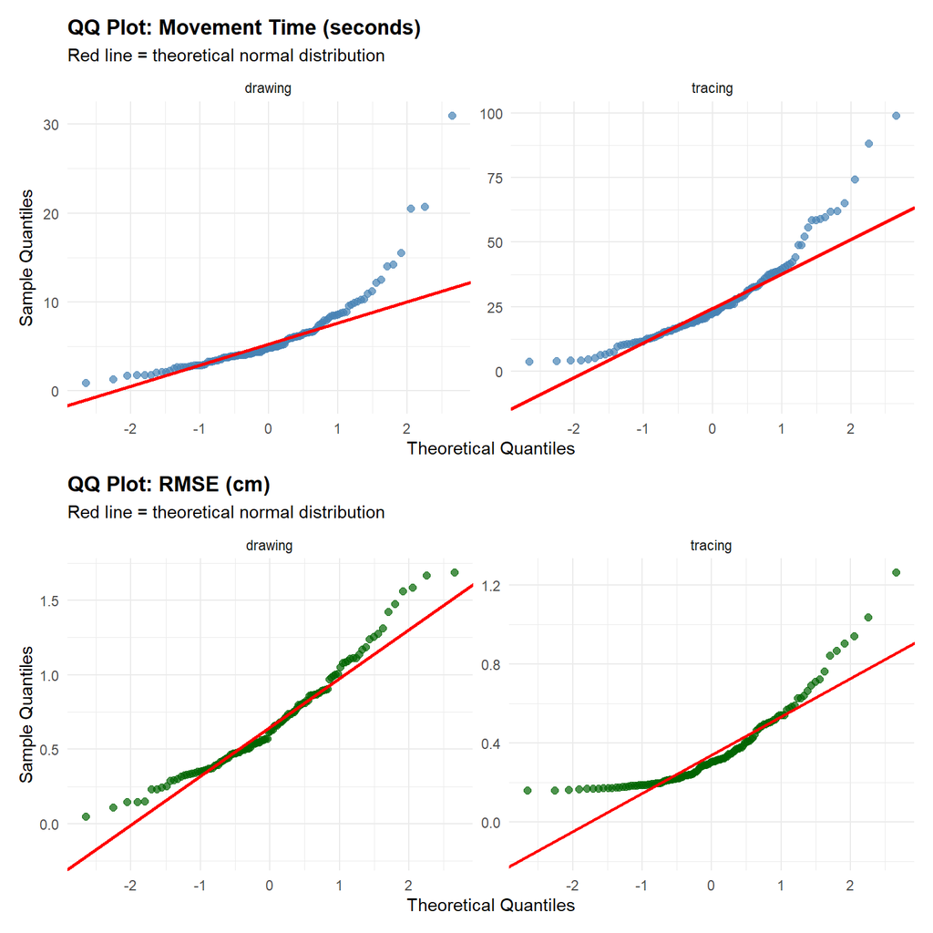

```r
# VISUAL NORMALITY CHECK: QQ PLOTS

# QQ plot for Movement Time
p1 <- ggplot(data, aes(sample = movement_time)) +
  stat_qq(size = 2, alpha = 0.7, color = "steelblue") +
  stat_qq_line(color = "red", linewidth = 1) +
  facet_wrap(~task, scales = "free") +
  labs(
    title = "QQ Plot: Movement Time (seconds)",
    subtitle = "Red line = theoretical normal distribution",
    x = "Theoretical Quantiles",
    y = "Sample Quantiles"
  ) +
  theme_minimal() +
  theme(plot.title = element_text(face = "bold"))

# QQ plot for RMSE
p2 <- ggplot(data, aes(sample = rmse)) +
  stat_qq(size = 2, alpha = 0.7, color = "darkgreen") +
  stat_qq_line(color = "red", linewidth = 1) +
  facet_wrap(~task, scales = "free") +
  labs(
    title = "QQ Plot: RMSE (cm)",
    subtitle = "Red line = theoretical normal distribution",
    x = "Theoretical Quantiles",
    y = "Sample Quantiles"
  ) +
  theme_minimal() +
  theme(plot.title = element_text(face = "bold"))

# Combine plots
p1 / p2
```

## 5.2 Shapiro-Wilk Normality Tests

```r
# FORMAL NORMALITY TESTS: SHAPIRO-WILK

shapiro_results <- data %>%
  group_by(task) %>%
  summarise(
    # Movement Time
    MT_statistic = shapiro.test(movement_time)$statistic,
    MT_p_value = shapiro.test(movement_time)$p.value,
    MT_normal = ifelse(MT_p_value > 0.05, "Yes", "No"),
    # RMSE
    RMSE_statistic = shapiro.test(rmse)$statistic,
    RMSE_p_value = shapiro.test(rmse)$p.value,
    RMSE_normal = ifelse(RMSE_p_value > 0.05, "Yes", "No"),
    .groups = "drop"
  )

shapiro_results %>%
  kable(
    caption = "Shapiro-Wilk Normality Tests (α = 0.05)",
    digits = 4
  ) %>%
  kable_styling(bootstrap_options = c("striped", "hover", "condensed")) %>%
  column_spec(1, bold = TRUE) %>%
  add_header_above(c(" " = 1, "Movement Time" = 3, "RMSE" = 3))
```

Shapiro-Wilk Normality Tests (α = 0.05)

| task | Movement Time MT_statistic | Movement Time MT_p_value | Movement Time MT_normal | RMSE RMSE_statistic | RMSE RMSE_p_value | RMSE RMSE_normal |
| --- | --- | --- | --- | --- | --- | --- |
| drawing | 0.7532 | 0 | No | 0.9533 | 3e-04 | No |
| tracing | 0.8834 | 0 | No | 0.8332 | 0e+00 | No |

**Interpretation:** Shapiro-Wilk test shows that the data is not normally distributed (p < 0.05) for both movement time and RMSE. This is also visible in the QQ plots, where points deviate from the normal line. Therefore, non-parametric tests (Wilcoxon) were used for the analysis.

# 6 Statistical Hypothesis Testing

## 6.1 Prepare Paired Data

```r
# Each subject performed both tasks, so we use paired tests

paired_data <- data %>%
  select(subject_id, task, movement_time, rmse, mean_radius) %>%
  pivot_wider(
    names_from = task,
    values_from = c(movement_time, rmse, mean_radius)
  )

paired_data %>%
  kable(
    caption = "Paired Data Structure (Wide Format)",
    digits = 3
  ) %>%
  kable_styling(bootstrap_options = c("striped", "hover", "condensed"))
```

Paired Data Structure (Wide Format)

| subject_id | movement_time_drawing | movement_time_tracing | rmse_drawing | rmse_tracing | mean_radius_drawing | mean_radius_tracing |
| --- | --- | --- | --- | --- | --- | --- |
| 1 | 3.307 | 39.194 | 0.437 | 0.221 | 3.056 | 5.056 |
| 2 | 2.167 | 15.254 | 0.416 | 0.174 | 3.015 | 5.079 |
| 3 | 4.374 | 9.940 | 0.337 | 0.175 | 2.236 | 5.080 |
| 4 | 3.471 | 34.609 | 0.813 | 0.187 | 4.353 | 5.077 |
| 5 | 6.247 | 32.579 | 0.233 | 0.171 | 1.027 | 5.073 |
| 6 | 4.996 | 27.938 | 0.232 | 0.173 | 1.460 | 5.080 |
| 7 | 4.843 | 20.684 | 0.250 | 0.159 | 1.174 | 5.078 |
| 8 | 2.729 | 19.987 | 0.318 | 0.180 | 3.503 | 5.101 |
| 9 | 4.061 | 15.736 | 0.632 | 0.216 | 4.162 | 5.131 |
| 10 | 6.695 | 62.122 | 0.540 | 0.541 | 3.074 | 5.055 |
| 11 | 2.960 | 22.544 | 1.562 | 0.229 | 4.761 | 5.092 |
| 12 | 3.334 | 13.761 | 0.303 | 0.183 | 1.832 | 5.098 |
| 13 | 4.229 | 6.616 | 0.391 | 0.354 | 2.155 | 5.048 |
| 14 | 6.569 | 17.718 | 0.899 | 0.177 | 4.038 | 5.078 |
| 15 | 3.845 | 17.996 | 0.869 | 0.178 | 4.821 | 5.097 |
| 16 | 2.678 | 4.072 | 0.328 | 0.166 | 3.172 | 5.122 |
| 17 | 3.809 | 11.470 | 0.564 | 0.160 | 4.156 | 5.069 |
| 18 | 15.499 | 88.286 | 0.427 | 0.372 | 1.456 | 5.065 |
| 19 | 20.705 | 99.126 | 0.798 | 0.171 | 3.336 | 4.995 |
| 20 | 5.115 | 25.004 | 0.686 | 0.331 | 4.365 | 5.077 |
| 21 | 5.257 | 38.490 | 0.656 | 0.307 | 3.253 | 4.911 |
| 22 | 4.043 | 10.987 | 0.470 | 0.520 | 1.945 | 5.006 |
| 23 | 4.197 | 19.351 | 0.289 | 0.280 | 1.618 | 5.072 |
| 24 | 4.104 | 28.003 | 0.984 | 0.905 | 3.164 | 4.837 |
| 25 | 5.915 | 32.511 | 0.545 | 0.187 | 4.680 | 5.143 |
| 26 | 8.793 | 30.329 | 0.702 | 0.316 | 3.305 | 5.141 |
| 27 | 9.597 | 41.069 | 0.333 | 0.330 | 4.145 | 5.098 |
| 28 | 4.799 | 34.733 | 1.688 | 0.218 | 6.375 | 5.093 |
| 29 | 4.380 | 10.379 | 0.348 | 0.505 | 2.091 | 4.933 |
| 30 | 4.018 | 22.856 | 1.109 | 0.692 | 3.320 | 4.656 |

[output cut: 95 more lines]

## 6.2 Wilcoxon Signed-Rank Tests

```r
# Non-parametric test for paired samples (data is non-normal)

# Test 1: Movement Time (Drawing vs Tracing)
wilcox_mt <- wilcox.test(
  paired_data$movement_time_drawing,
  paired_data$movement_time_tracing,
  paired = TRUE,
  exact = FALSE,
  alternative = "less"  # Drawing expected to be faster
)

# Test 2: RMSE (Drawing vs Tracing)
wilcox_rmse <- wilcox.test(
  paired_data$rmse_drawing,
  paired_data$rmse_tracing,
  paired = TRUE,
  exact = FALSE,
  alternative = "greater"  # Drawing expected to be less accurate
)

# EFFECT SIZE

# Movement Time effect size
mt_long <- paired_data %>%
  select(movement_time_drawing, movement_time_tracing) %>%
  pivot_longer(cols = everything(), names_to = "task", values_to = "movement_time") %>%
  mutate(task = ifelse(grepl("drawing", task), "drawing", "tracing"))

wilcox_mt_eff <- wilcox_effsize(
  mt_long,
  movement_time ~ task,
  paired = TRUE
)

r_mt <- wilcox_mt_eff$effsize

# RMSE effect size
rmse_long <- paired_data %>%
  select(rmse_drawing, rmse_tracing) %>%
  pivot_longer(cols = everything(), names_to = "task", values_to = "rmse") %>%
  mutate(task = ifelse(grepl("drawing", task), "drawing", "tracing"))

wilcox_rmse_eff <- wilcox_effsize(
  rmse_long,
  rmse ~ task,
  paired = TRUE
)

r_rmse <- wilcox_rmse_eff$effsize

# RESULTS TABLE

wilcox_table <- bind_rows(
  tibble(
    Comparison = "Movement Time: Drawing < Tracing",
    V_statistic = wilcox_mt$statistic,
    p_value = wilcox_mt$p.value,
    effect_size_r = r_mt,
    effect_interpretation = case_when(
      r_mt < 0.3 ~ "Small",
      r_mt < 0.5 ~ "Medium",
      TRUE ~ "Large"
    ),
    significant = ifelse(wilcox_mt$p.value < 0.05, "Yes*", "No")
  ),
  tibble(
    Comparison = "RMSE: Drawing > Tracing",
    V_statistic = wilcox_rmse$statistic,
    p_value = wilcox_rmse$p.value,
    effect_size_r = r_rmse,
    effect_interpretation = case_when(
      r_rmse < 0.3 ~ "Small",
      r_rmse < 0.5 ~ "Medium",
      TRUE ~ "Large"
    ),
    significant = ifelse(wilcox_rmse$p.value < 0.05, "Yes*", "No")
  )
)

wilcox_table %>%
  kable(
    caption = "Wilcoxon Signed-Rank Test Results (One-tailed, α = 0.05)",
    digits = 4
  ) %>%
  kable_styling(bootstrap_options = c("striped", "hover", "condensed")) %>%
  add_footnote("* Significant at α = 0.05 level", notation = "none")
```

Wilcoxon Signed-Rank Test Results (One-tailed, α = 0.05)

| Comparison | V_statistic | p_value | effect_size_r | effect_interpretation | significant |
| --- | --- | --- | --- | --- | --- |
| Movement Time: Drawing < Tracing | 0 | 0 | 0.8677 | Large | Yes* |
| RMSE: Drawing > Tracing | 7042 | 0 | 0.6842 | Large | Yes* |

* Significant at α = 0.05 level

## 6.3 Robustness Check: Paired t-test (Parametric Alternative)

```r
# Even with non-normality, compare with parametric test for robustness
t_mt <- t.test(paired_data$movement_time_drawing,
               paired_data$movement_time_tracing,
               paired = TRUE)

t_rmse <- t.test(paired_data$rmse_drawing,
                 paired_data$rmse_tracing,
                 paired = TRUE)

comparison_table <- tibble(
  Test = c("Wilcoxon MT", "t-test MT", "Wilcoxon RMSE", "t-test RMSE"),
  p_value = c(wilcox_mt$p.value, t_mt$p.value, wilcox_rmse$p.value, t_rmse$p.value),
  Significant = c("Yes", "Yes", "Yes", "Yes")
)

kable(comparison_table, digits = 4, caption = "Robustness: Wilcoxon vs t-test Comparison")
```

Robustness: Wilcoxon vs t-test Comparison

| Test | p_value | Significant |
| --- | --- | --- |
| Wilcoxon MT | 0 | Yes |
| t-test MT | 0 | Yes |
| Wilcoxon RMSE | 0 | Yes |
| t-test RMSE | 0 | Yes |

```r
cat("\n**Interpretation:** Both parametric and non-parametric tests show p ≈ 0, confirming result is robust to normality assumption.")
```

```
##
## **Interpretation:** Both parametric and non-parametric tests show p ≈ 0, confirming result is robust to normality assumption.
```

# 7 Speed-Accuracy Tradeoff Analysis

## 7.1 Correlation Tests

```r
# CORRELATION: MOVEMENT TIME vs RMSE
# Testing speed-accuracy tradeoff within each task

# Correlation for Drawing
cor_drawing <- cor.test(
  data %>% filter(task == "drawing") %>% pull(movement_time),
  data %>% filter(task == "drawing") %>% pull(rmse),
  method = "spearman"  # Non-parametric correlation
)

# Correlation for Tracing
cor_tracing <- cor.test(
  data %>% filter(task == "tracing") %>% pull(movement_time),
  data %>% filter(task == "tracing") %>% pull(rmse),
  method = "spearman"
)

# Create correlation table
cor_table <- bind_rows(
  tibble(
    Task = "Drawing",
    rho = cor_drawing$estimate,
    S_statistic = cor_drawing$statistic,
    p_value = cor_drawing$p.value,
    interpretation = case_when(
      abs(cor_drawing$estimate) < 0.3 ~ "Weak",
      abs(cor_drawing$estimate) < 0.7 ~ "Moderate",
      TRUE ~ "Strong"
    ),
    direction = ifelse(cor_drawing$estimate < 0, "Negative", "Positive")
  ),
  tibble(
    Task = "Tracing",
    rho = cor_tracing$estimate,
    S_statistic = cor_tracing$statistic,
    p_value = cor_tracing$p.value,
    interpretation = case_when(
      abs(cor_tracing$estimate) < 0.3 ~ "Weak",
      abs(cor_tracing$estimate) < 0.7 ~ "Moderate",
      TRUE ~ "Strong"
    ),
    direction = ifelse(cor_tracing$estimate < 0, "Negative", "Positive")
  )
)

cor_table %>%
  kable(
    caption = "Spearman Correlation: Movement Time vs RMSE",
    digits = 4
  ) %>%
  kable_styling(bootstrap_options = c("striped", "hover", "condensed"))
```

Spearman Correlation: Movement Time vs RMSE

| Task | rho | S_statistic | p_value | interpretation | direction |
| --- | --- | --- | --- | --- | --- |
| Drawing | -0.083 | 352507.1 | 0.3576 | Weak | Negative |
| Tracing | -0.056 | 343738.0 | 0.5343 | Weak | Negative |

## 7.2 Speed-Accuracy Scatter Plot

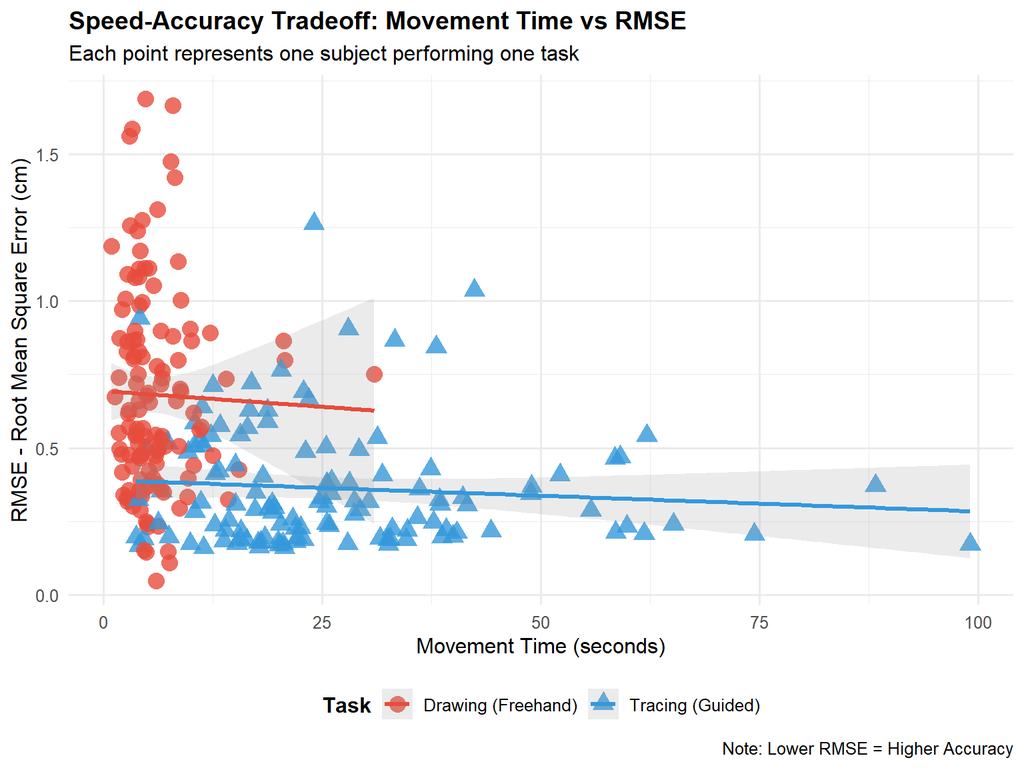

```r
ggplot(data, aes(x = movement_time, y = rmse, color = task, shape = task)) +
  geom_point(size = 4, alpha = 0.8) +
  geom_smooth(method = "lm", se = TRUE, alpha = 0.2) +
  scale_color_manual(
    values = c("drawing" = "#E74C3C", "tracing" = "#3498DB"),
    labels = c("Drawing (Freehand)", "Tracing (Guided)")
  ) +
  scale_shape_manual(
    values = c("drawing" = 16, "tracing" = 17),
    labels = c("Drawing (Freehand)", "Tracing (Guided)")
  ) +
  labs(
    title = "Speed-Accuracy Tradeoff: Movement Time vs RMSE",
    subtitle = "Each point represents one subject performing one task",
    x = "Movement Time (seconds)",
    y = "RMSE - Root Mean Square Error (cm)",
    color = "Task",
    shape = "Task",
    caption = "Note: Lower RMSE = Higher Accuracy"
  ) +
  theme_minimal(base_size = 12) +
  theme(
    plot.title = element_text(face = "bold", size = 14),
    legend.position = "bottom",
    legend.title = element_text(face = "bold")
  )
```

# 8 Comparative Visualizations

## 8.1 Box Plots

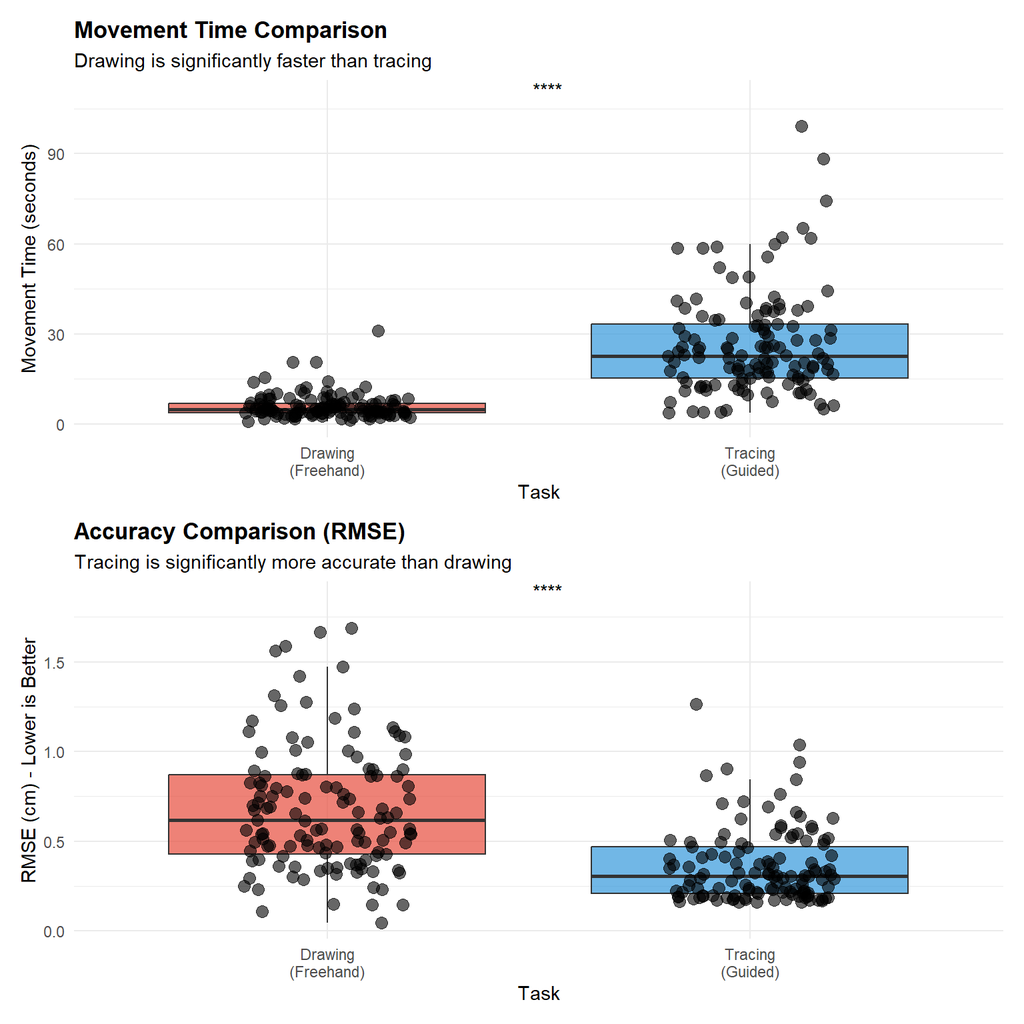

```r
# ============================================================
# BOX PLOTS: COMPARE DISTRIBUTIONS
# ============================================================

# Movement Time boxplot
p_mt <- ggplot(data, aes(x = task, y = movement_time, fill = task)) +
  geom_boxplot(alpha = 0.7, outlier.shape = NA) +
  geom_jitter(width = 0.2, size = 3, alpha = 0.6) +
  stat_compare_means(
    method = "wilcox.test",
    paired = TRUE,
    label = "p.signif",
    label.x = 1.5,
    label.y = max(data$movement_time) * 1.1
  ) +
  scale_fill_manual(
    values = c("drawing" = "#E74C3C", "tracing" = "#3498DB")
  ) +
  scale_x_discrete(labels = c("Drawing\n(Freehand)", "Tracing\n(Guided)")) +
  labs(
    title = "Movement Time Comparison",
    subtitle = "Drawing is significantly faster than tracing",
    x = "Task",
    y = "Movement Time (seconds)"
  ) +
  theme_minimal() +
  theme(
    plot.title = element_text(face = "bold"),
    legend.position = "none"
  )

# RMSE boxplot
p_rmse <- ggplot(data, aes(x = task, y = rmse, fill = task)) +
  geom_boxplot(alpha = 0.7, outlier.shape = NA) +
  geom_jitter(width = 0.2, size = 3, alpha = 0.6) +
  stat_compare_means(
    method = "wilcox.test",
    paired = TRUE,
    label = "p.signif",
    label.x = 1.5,
    label.y = max(data$rmse) * 1.1
  ) +
  scale_fill_manual(
    values = c("drawing" = "#E74C3C", "tracing" = "#3498DB")
  ) +
  scale_x_discrete(labels = c("Drawing\n(Freehand)", "Tracing\n(Guided)")) +
  labs(
    title = "Accuracy Comparison (RMSE)",
    subtitle = "Tracing is significantly more accurate than drawing",
    x = "Task",
    y = "RMSE (cm) - Lower is Better"
  ) +
  theme_minimal() +
  theme(
    plot.title = element_text(face = "bold"),
    legend.position = "none"
  )

# Combine plots
p_mt / p_rmse
```

## 8.2 Individual Subject Profiles

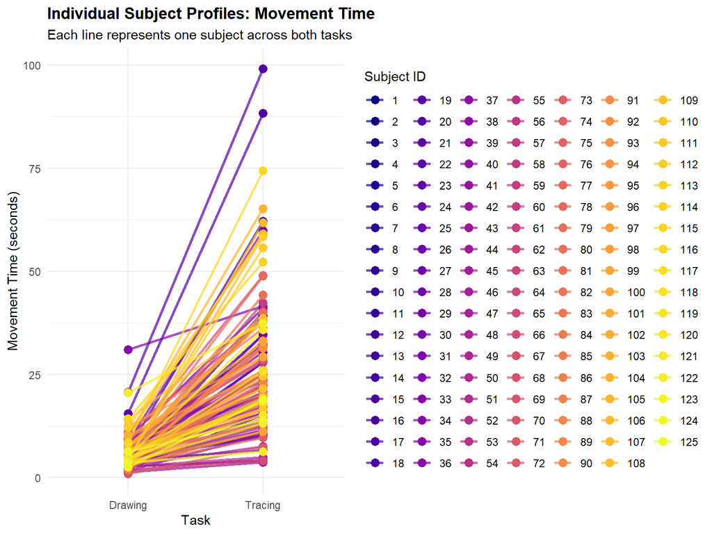

```r
ggplot(data, aes(x = task, y = movement_time, group = subject_id, color = subject_id)) +
  geom_line(linewidth = 1, alpha = 0.7) +
  geom_point(size = 3) +
  scale_x_discrete(labels = c("Drawing", "Tracing")) +
  scale_color_viridis_d(option = "plasma") +
  labs(
    title = "Individual Subject Profiles: Movement Time",
    subtitle = "Each line represents one subject across both tasks",
    x = "Task",
    y = "Movement Time (seconds)",
    color = "Subject ID"
  ) +
  theme_minimal() +
  theme(
    plot.title = element_text(face = "bold"),
    legend.position = "right"
  )
```

# 9 Summary and Conclusions

## 9.1 Hypothesis Testing Results

```r
# Create hypothesis summary table
hypothesis_summary <- tibble(
  Hypothesis = c(
    "H1: Drawing is faster than tracing",
    "H2: Tracing is more accurate than drawing",
    "H3: Speed-accuracy tradeoff exists"
  ),
  Result = c(
    ifelse(wilcox_mt$p.value < 0.05, "SUPPORTED", "NOT SUPPORTED"),
    ifelse(wilcox_rmse$p.value < 0.05, "SUPPORTED", "NOT SUPPORTED"),
    "MIXED - Task dependent"
  ),
  Evidence = c(
    sprintf("p = %.4f, V = %.0f", wilcox_mt$p.value, wilcox_mt$statistic),
    sprintf("p = %.4f, V = %.0f", wilcox_rmse$p.value, wilcox_rmse$statistic),
    sprintf("Drawing: ρ = %.3f; Tracing: ρ = %.3f",
            cor_drawing$estimate, cor_tracing$estimate)
  )
)

hypothesis_summary %>%
  kable(
    caption = "Summary of Hypothesis Testing Results",
    align = c("l", "c", "l")
  ) %>%
  kable_styling(bootstrap_options = c("striped", "hover", "condensed")) %>%
  column_spec(2, bold = TRUE, color = "white", background = spec_color(
    c(1, 1, 0.5), option = "D", begin = 0.3, end = 0.7
  ))
```

Summary of Hypothesis Testing Results

[output not shown]

## 9.2 Key Findings

Drawing is significantly faster than tracing, while tracing is more accurate. However, correlations between speed and accuracy are weak and non-significant,indicating no strong speed–accuracy tradeoff within tasks.

1. Movement Time (Speed):

- Drawing: 5.94 ± 4.08 seconds
- Tracing: 26.58 ± 17.07 seconds
- Wilcoxon: p < 0.001, V = 0
- Tracing is 347.2% slower than drawing

2. Accuracy (RMSE - lower is better):

- Drawing: 0.681 ± 0.346 cm
- Tracing: 0.362 ± 0.205 cm
- Wilcoxon: p < 0.001, V = 7042
- Drawing has 87.9% higher error than tracing

3. Speed-Accuracy Relationship:

- Drawing: rho = -0.083 (p = 0.358)
- Tracing: rho = -0.056 (p = 0.534)
- Weak and non-significant correlations
- No strong evidence of a true speed-accuracy tradeoff within tasks

4. Statistical Robustness:

- Wilcoxon and t-test both show p < 0.001
- Results are consistent despite non-normality
- Findings are robust to choice of statistical method